# Rのインストール（Windows）

# 目的

Rの自習環境をWindows上に構築します．

# Rのダウンロード

Rの配布先であるThe Comprehensive R Archive Network(CRAN)から R for Windows バージョンx.x.x をダウンロードします．

※バージョンは最新のものをインストールします．

[figure not shown]

「Download and Install」にある「Download R for Windows」をクリックします．

[figure not shown]

「Subdirectories」にある「base」をクリックします．

[figure not shown]

最新バージョンのRをダウンロードする場合は「Download R X.X.X for Windows」をクリックします．ここでは旧バージョン(R x.x.x)をダウンロードするため下にスクロールします．

[figure not shown]

ページの下の方，「Other builds」にある「Previous releases」をクリックします．

[figure not shown]

[figure not shown]

# Rのインストール

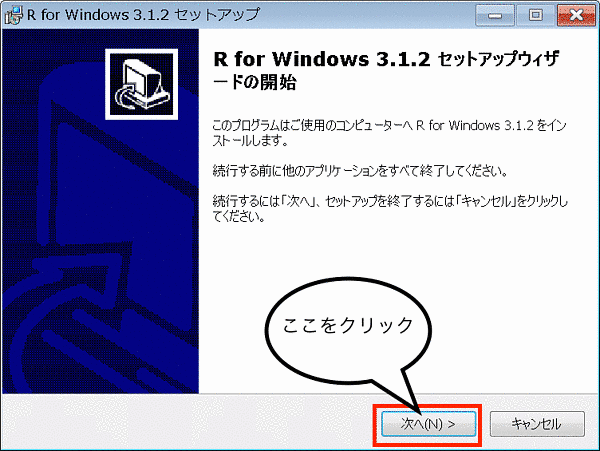

ライセンス条項を確認し「次へ」をクリックします．

[figure not shown]

インストール先を確認し「次へ」をクリックします．

[figure not shown]

インストールするコンポーネントを選択します．デフォルトのまま「次へ」をクリックします．

[figure not shown]

「いいえ」を選択し「次へ」をクリックします．

[figure not shown]

「次へ」をクリックします．

[figure not shown]

「次へ」をクリックします．

[figure not shown]

インストールが終わるまでしばらく待ちます．

[figure not shown]

「完了」をクリックします．

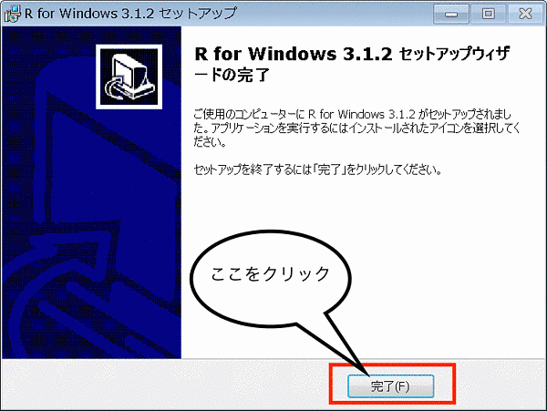

Masaharu Hayashi を著作者とするこの 作品 は [クリエイティブ・コモンズの 表示 4.0 国際 ライセンス](http://creativecommons.org/licenses/by/4.0/)で提供されています。